# Climate Scientist Coding Challenge

This is an open-ended assessment which gives you a chance to demonstrate:

- expertise of climate dynamics and subseasonal-to-seasonal (S2S) teleconnections
- proficiency with standard geospatial analysis toolsets
- creativity and ability to quickly prototype a solution

We have provided you with a 70-year sample dataset of several climate variables from the ERA5 reanalysis. The data are reprocessed to weekly resolution on a 1° grid. Your assignment is to:

- choose a single geo coordinate (or aggregated region) in the dataset to predict
- choose a single variable to predict
- choose a forecast lead time between 2-52 weeks
- build a statistical, physical, or machine learning predictive model
- test and analyze its predictive performance by applying it to out of sample data

You should aim for the most predictive model you can, and choose your geographic domain and input variables accordingly. Time limit is two hours - we don't want this to be a second job for you. If you are not done after two hours, it is OK to submit a partial answer.

```python
# Some useful libraries available in this environment
import xarray as xr
import pandas as pd
import numpy as np
#from eofs.xarray import Eof
import xesmf as xe
import matplotlib.pyplot as plt
import tensorflow as tf
import sklearn as sk
import xskillscore as xs
import cartopy.crs as ccrs
import cartopy.feature as cfeature
from scipy import signal
from eofs.standard import Eof
from mpl_toolkits.basemap import Basemap
from scipy.stats import pearsonr
```

```python
# Open the sample dataset for this assignment from cloud storage
ds = xr.open_zarr('gs://salient-toy-data/sample_dataset')
```

```python
# Let's treat the variables as anomalies from historical averages:
anom = ds - ds.mean()

# Can we predict temperature anomalies in San Diego using sea level pressure in the gulf of california?
sd_temp = anom.temp.sel(lon = -117, lat = 33, method = 'nearest')
ca_mslp = anom.mslp.sel(lon = slice(-115, -105), lat = slice(24, 32)).mean(['lat','lon']).shift(time = -8).compute()
```

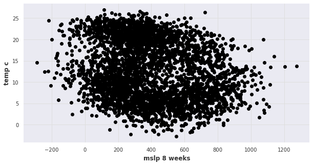

```python
# Eyeball test - are we on the right track?
plt.figure(figsize=[10, 5])
ax = plt.subplot(1,1,1)
plt.scatter(ca_mslp, sd_temp)
plt.xlabel('mslp 8 weeks')
plt.ylabel('temp c')
```

```python
# Oh no, that correlation looks terrible!
# We need a climate scientist to identify and exploit a better relationship
```

## Declaring variables and making them anamolies

```python
mslp = xr.open_zarr('gs://salient-toy-data/sample_dataset')['mslp']
temp = xr.open_zarr('gs://salient-toy-data/sample_dataset')['temp']
sst = xr.open_zarr('gs://salient-toy-data/sample_dataset')['sst']
```

```python
mslp = mslp - mslp.mean(dim='time')
temp = temp - temp.mean(dim='time')
sst = sst - sst.mean(dim='time')
```

```python
# Make the yearly and mean of the sample dataset

mslp_ya = mslp.resample(time='1YS').mean()
temp_ya = temp.resample(time='1YS').mean()
sst_ya = sst.resample(time='1YS').mean()

mslp_ma= mslp.resample(time='1MS').mean()
temp_ma = temp.resample(time='1MS').mean()
```

```python
# Converting the xarray dataarray to numpy array because of the eof analysis of xarray
# throwing some error due to dask performance issue. It is going to take a while to convert.

mslp_ma_np = mslp_ma.to_numpy()
temp_ma_np = temp_ma.to_numpy()

mslp_ya_np = mslp_ya.to_numpy()
sst_ya_np = sst_ya.to_numpy()
```

```python
# Reading lat and lon

lat = mslp_ma.coords['lat']
lat = lat.to_numpy()
lon = mslp_ma.coords['lon']
lon = lon.to_numpy()
```

### Masking the land surface for sst visualization

```python
from netCDF4 import Dataset as netcdf # netcdf4-python module



lmfile = 'lsmask.nc'
lmset  = netcdf(lmfile)
lsmask = lmset['mask'][0,:,:]

lsm = lsmask + 1
lsm[lsm<1.0] = np.nan
```

```python
sst_ya_np = sst_ya_np*lsm
```

## Finding the proper correlationship

In this part, we are going to find the spatial correlationship with the MSLP and Temperature and visualize it for the San diego location.

```python
# Declaring some initial variable required for calculation

nt,nlat,nlon = mslp_ma_np.shape


ngrd = nlat*nlon
nyr  = nt/12
```

### Remove seasonal cycle

```python
mslp_grd  = mslp_ma_np.reshape((12,int(nyr), ngrd), order='F').transpose((1,0,2))
mslp_clim = np.mean(mslp_grd, axis=0)
mslp_anom = (mslp_grd - mslp_clim).transpose((1,0,2)).reshape((nt, ngrd), order='F')

print(mslp_anom[:,1].shape)

temp_grd  = temp_ma_np.reshape((12,int(nyr), ngrd), order='F').transpose((1,0,2))
temp_clim = np.mean(temp_grd, axis=0)
temp_anom = (temp_grd - temp_clim).transpose((1,0,2)).reshape((nt, ngrd), order='F')

print(temp_anom[:,1].shape)
```

```
(840,)
(840,)
```

### Calculate correlationship

```python
corr = np.zeros((1, ngrd))
pval = np.zeros((1, ngrd))

for igrd in np.arange(ngrd):
    crr,pvalue = pearsonr(temp_anom[:,igrd], mslp_anom[:,igrd])
    corr[0,igrd] = crr
    pval[0,igrd] = pvalue
```

```python
corr = corr.reshape((nlat,nlon), order='F')
pval = pval.reshape((nlat,nlon), order='F')
```

### Visualize

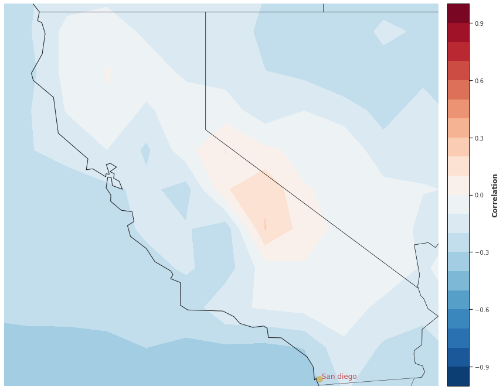

```python
# Correlation visualize


fig = plt.figure(figsize=(20,12))


m = Basemap(llcrnrlon=-125.1,llcrnrlat=32.52,urcrnrlon=-114.1,urcrnrlat=42.2,\
            rsphere=(6378137.00,6356752.3142),\
            resolution='l',projection='cyl',\
            lat_0=36.38,lon_0=-119.63)


x, y = m(*np.meshgrid(lon,lat))


clevs = np.linspace(-1.0, 1.0, 21)

cs = m.contourf(x, y, corr.squeeze(), clevs, cmap=plt.cm.RdBu_r)
m.drawcoastlines()
m.drawcountries()
m.drawstates(linewidth=0.5, linestyle='solid', color='k', antialiased=1, ax=None, zorder=None)
san_diego_lat = 32.7; san_diego_lon=-117.12
x1,y1=m(san_diego_lon,san_diego_lat)
plt.plot(x1, y1, 'oy', markersize=10)
plt.text(x1,y1, ' San diego', fontsize=12,color='r');
cb = m.colorbar(cs)
cb.set_label('Correlation', fontsize=12)
ax.set_title('temperature and mslp correlation in california', fontsize=16)
```

# EOF analysis of the Atmospheric Variables

Atmospheric teleconnection patterns influence the global climate through the atmospheric circulation Especially, the El Ni˜no–Southern Oscillation (ENSO) has a significant effect on humanity’s economic, social, and physical well-being. Many studies have been devoted to predict the extreme weather conditions of different regions of the globe in association with the ENSO. We are examining the leading EOF of different atmospheric variable,SST in the following case. the following methodology is inspired from the following [blogs](https://podaac.jpl.nasa.gov/forum/viewtopic.php?f=5&t=337) and my previous [work](https://mdsoar.org/bitstream/handle/11603/16929/CT2019Team2.pdf?sequence=1&isAllowed=y).

```python
# Working with yearly average for better impact study


nt,nlat,nlon = sst_ya_np.shape
sst_ya_np = sst_ya_np.reshape((nt,nlat*nlon), order='F')
```

### Detrending the varaible

```python
sst_ya_np = np.nan_to_num(sst_ya_np)
```

```python
sst_detrend = signal.detrend(sst_ya_np, axis=0, type='linear', bp=0)


sst_detrend = sst_detrend.reshape((nt,nlat,nlon), order='F')
print(sst_detrend.shape)
```

```
(70, 180, 360)
```

### Create an EOF solver to do the EOF analysis

```python
wgts   = np.cos(np.deg2rad(mslp_ma.coords['lat'].values))
wgts   = wgts.reshape(len(wgts), 1)

solver = Eof(sst_detrend,weights=wgts)
```

### Retreive the leading EOFs

```python
eof1 = solver.eofs(neofs=10)
pc1  = solver.pcs(npcs=10, pcscaling=0)
varfrac = solver.varianceFraction()
lambdas = solver.eigenvalues()
```

### Visualize the leading EOFs and Primary Components (PC)

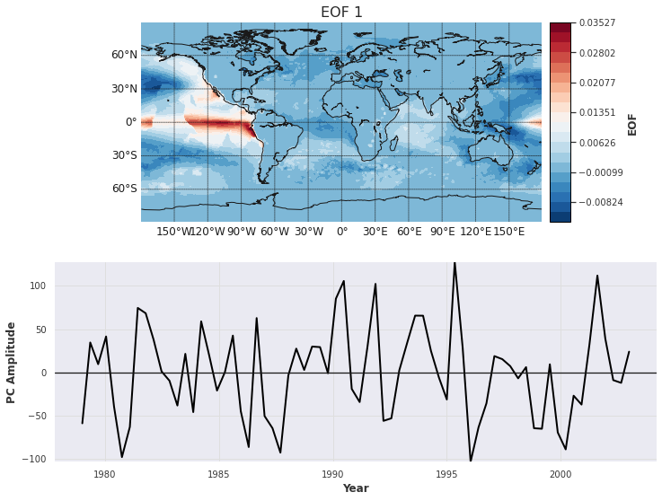

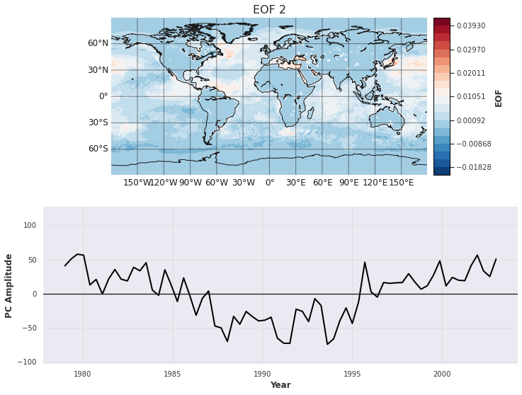

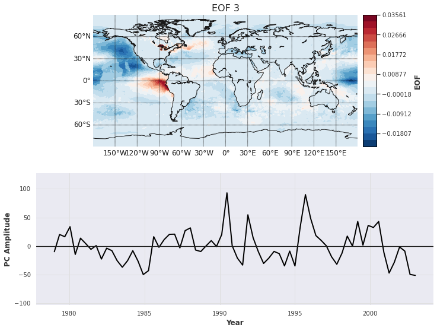

```python
parallels = np.arange(-90,90,30.)
meridians = np.arange(-180,180,30)

for i in range(0,3):
    fig = plt.figure(figsize=(12,9))
    plt.subplot(211)

    m = Basemap(projection='cyl', llcrnrlon=min(lon), llcrnrlat=min(lat), urcrnrlon=max(lon), urcrnrlat=max(lat))
    x, y = m(*np.meshgrid(lon, lat))
    clevs = np.linspace(np.min(eof1[i,:,:].squeeze()), np.max(eof1[i,:,:].squeeze()), 21)
    cs = m.contourf(x, y, eof1[i,:,:].squeeze(), clevs, cmap=plt.cm.RdBu_r)
    m.drawcoastlines()
    m.drawparallels(parallels, labels=[1,0,0,0])
    m.drawmeridians(meridians, labels=[1,0,0,1])

    cb = m.colorbar(cs, 'right', size='5%', pad='2%')
    cb.set_label('EOF', fontsize=12)
    plt.title('EOF ' + str(i+1), fontsize=16)

    plt.subplot(212)
    days = np.linspace(1979,2003,nt)
    plt.plot(days, pc1[:,i], linewidth=2)
    plt.axhline(0, color='k')
    plt.xlabel('Year')
    plt.ylabel('PC Amplitude')
    plt.ylim(np.min(pc1.squeeze()), np.max(pc1.squeeze()))
```

There are large peaks and troughs associated with well-known El Nino and La Nina events in EOF1 figure, as well as the ecclesiastical El Nino pattern.

### Check variances explained by leading EOFs

[output not shown]

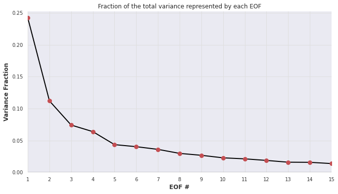

```python
plt.figure(figsize=(11,6))
eof_num = range(1, 16)
plt.plot(eof_num, varfrac[0:15], linewidth=2)
plt.plot(eof_num, varfrac[0:15], linestyle='None', marker="o", color='r', markersize=8)
plt.axhline(0, color='k')
plt.xticks(range(1, 16))
plt.title('Fraction of the total variance represented by each EOF')
plt.xlabel('EOF #')
plt.ylabel('Variance Fraction')
plt.xlim(1, 15)
plt.ylim(np.min(varfrac), np.max(varfrac)+0.01)
```

## Climatology Visualization

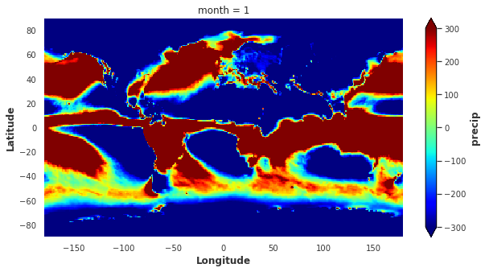

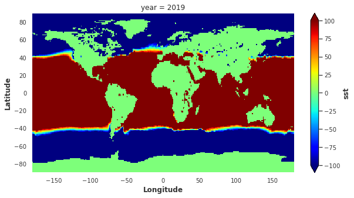

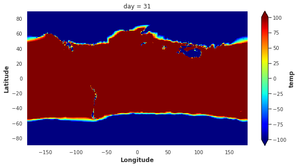

```python
# Monthly/Yearly/daily average for the atmospheric varabile in a global scale

anom_month = anom.groupby('time.month').sum()
anom_year = anom.groupby('time.year').sum()
anom_day = anom.groupby('time.day').sum()

anom_month.precip[0,:,:].plot(cmap='jet', vmax = 300,figsize =(10,5))
anom_year.sst[-1,:,:].plot(cmap='jet', vmax =100 ,figsize =(10,5))
anom_day.temp[-1,:,:].plot(cmap='jet', vmax =100 ,figsize =(10,5))
```

### Lets visualize it in a more organized way and see it in every month scale

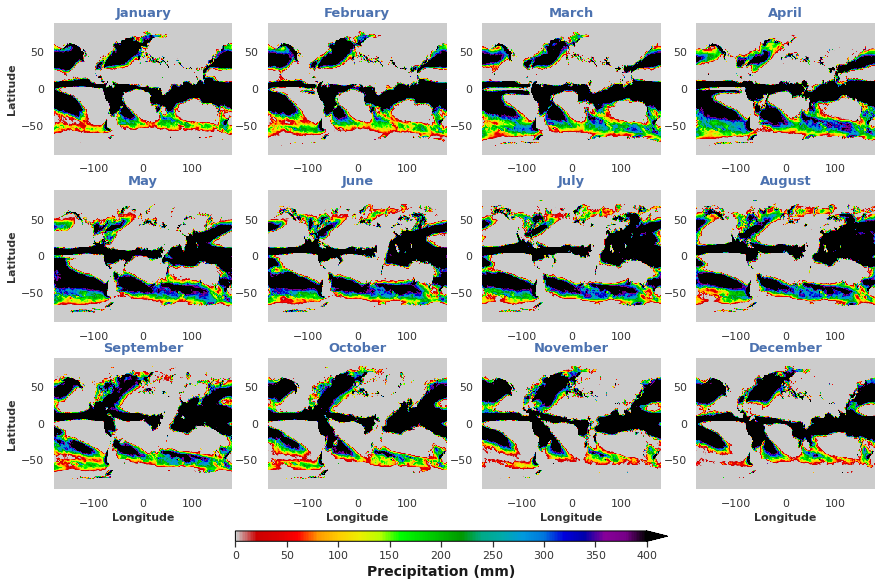

```python
# Monthly data for the average values of the atmospheric variables.

import calendar

fig = plt.figure(figsize=[12,8], facecolor='w')
plt.subplots_adjust(bottom=0.15, top=0.96, left=0.04, right=0.99,
                    wspace=0.2, hspace=0.27)
nrows = 3
ncols = 4
for i in range(1, 13):
    plt.subplot(nrows, ncols, i)
    dataplot = anom_month.precip[i-1, :, :]
    p = plt.pcolormesh(anom_month.precip.lon, anom_month.precip.lat, dataplot,
                   vmax = 400, vmin = 0, cmap = 'nipy_spectral_r',
                   )
    plt.xlim([-180,180])
    plt.ylim([-90,90])
    plt.title(calendar.month_name[dataplot.month.values], fontsize = 13,
              fontweight = 'bold', color = 'b')
    plt.xticks(fontsize = 11)
    plt.yticks(fontsize = 11)
    if i % ncols == 1: # Add ylabel for the very left subplots
        plt.ylabel('Latitude', fontsize = 11, fontweight = 'bold')
    if i > ncols*(nrows-1): # Add xlabel for the bottom row subplots
        plt.xlabel('Longitude', fontsize = 11, fontweight = 'bold')

# Add a colorbar at the bottom:
cax = fig.add_axes([0.25, 0.06, 0.5, 0.018])
cb = plt.colorbar(cax=cax, orientation='horizontal', extend = 'max',)
cb.ax.tick_params(labelsize=11)
cb.set_label(label='Precipitation (mm)', color = 'k', size=14)
```

### Visualizing Climatology for a specific location (California)

```python
#California bounding box values (xmin,xmax, ymin,ymax)

top = 42.00951
bottom = 32.534156
left = -124.409591
right = -114.131211
```

```python
ds_sel = anom.isel(lon=(anom.lon >= left) & (anom.lon <= right),
                          lat=(anom.lat >= bottom) & (anom.lat <= top),
                          )
ds_sel_avg = ds_sel.mean(dim=['lat','lon'])
```

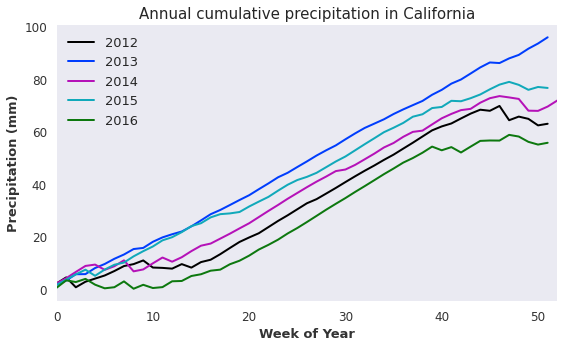

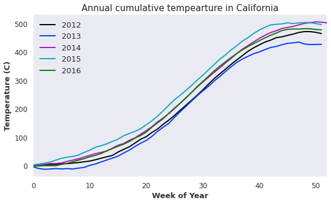

```python
fig = plt.figure(figsize=[8,5], facecolor='w')
for yr in range(2012,2017):
    da_yr = ds_sel_avg.isel(time = ds_sel.time.dt.year==yr).precip
    dataplot = abs(da_yr.cumsum())
    plt.plot(dataplot, linewidth=2, label = yr)
plt.legend(fontsize=13)
plt.grid()
plt.xticks(fontsize=12)
plt.yticks(fontsize=12)
plt.ylabel('Precipitation (mm)', fontsize = 13, fontweight = 'bold')
plt.xlabel('Week of Year', fontsize = 13, fontweight = 'bold')
plt.xlim([0,52])
plt.title('Annual cumulative precipitation in California', fontsize=15)
plt.tight_layout()


fig = plt.figure(figsize=[8,5], facecolor='w')
for yr in range(2012,2017):
    da_yr = ds_sel_avg.isel(time = ds_sel.time.dt.year==yr).temp
    dataplot = da_yr.cumsum()
    plt.plot(dataplot, linewidth=2, label = yr)
plt.legend(fontsize=13)
plt.grid()
plt.xticks(fontsize=12)
plt.yticks(fontsize=12)
plt.ylabel('Temperature (C)', fontsize = 13, fontweight = 'bold')
plt.xlabel('Week of Year', fontsize = 13, fontweight = 'bold')
plt.xlim([0,52])
plt.title('Annual cumulative tempearture in California', fontsize=15)
plt.tight_layout()
```

## Plot Global Monthly climatology

In this example, we are visualizing the monthly average temeprature climatology in a global scale.

```python
ntime,nrow,ncol = temp_ma_np.shape
tempym  = temp_ma_np.reshape((12,int(ntime/12), nrow,ncol),order='F')
tempclm = tempym.mean(axis=1)
tempclm.shape
```

```
(12, 180, 360)
```

```python
lons,lats = np.meshgrid(lon, lat)
```

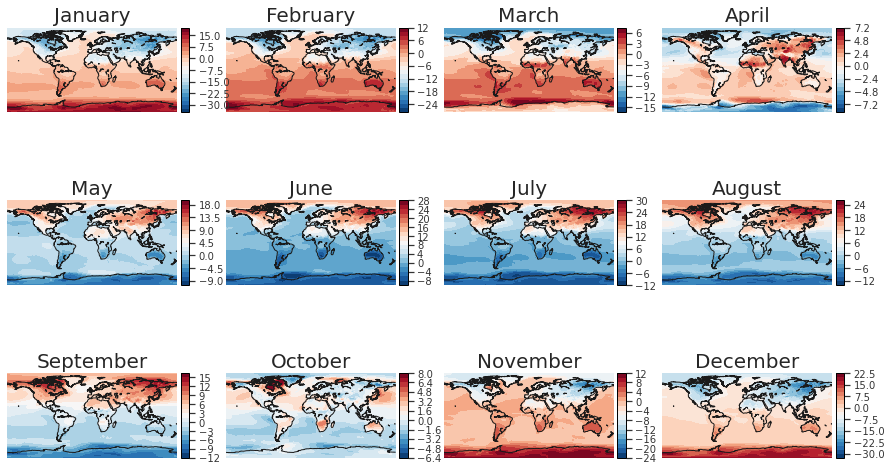

```python
from matplotlib.pylab import rcParams
rcParams['figure.figsize'] = 15, 9

fig, axes = plt.subplots(3,4)
flat_axes = axes.reshape(-1)
m = Basemap(projection='cyl',llcrnrlon=min(lon), llcrnrlat=min(lat),
        urcrnrlon=max(lon), urcrnrlat=max(lat))

# coordinates transformation
x, y = m(lons, lats)

# string month names
month_lst = ['January', 'February', 'March', 'April', 'May', 'June', 'July',
              'August', 'September', 'October', 'November', 'December']

imon = -1
for ax in flat_axes:
    m.ax = ax
    imon = imon + 1
    cssst = m.contourf(x,y,tempclm[imon], 20,cmap=plt.cm.RdBu_r)
    m.colorbar(cssst,"right", size="5%", pad='2%')
    plt.title( month_lst[imon], fontsize=20)
    m.drawcoastlines()
```

## Trend analysis of a given variable

In this following example, we are examing the temeprature changing rate and visualize it.

```python
nt, nlat, nlon = temp_ma_np.shape
ngrd = nlon*nlat
```

```python
temp_ma_np.shape
```

```
(840, 180, 360)
```

```python
temp_grd = temp_ma_np.reshape((nt, ngrd), order='F')
x        = np.linspace(1,nt,nt)#.reshape((nt,1))
temp_rate = np.empty((ngrd,1))
temp_rate[:,:] = np.nan
```

```python
for i in range(ngrd):
    y = temp_grd[:,i]
    if(not np.ma.is_masked(y)):
        z = np.polyfit(x, y, 1)
        temp_rate[i,0] = z[0]*120.0


temp_rate = temp_rate.reshape((nlat,nlon), order='F')
```

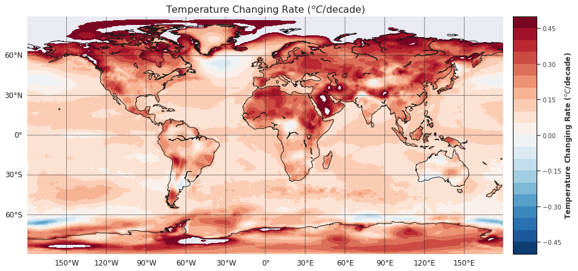

```python
parallels = np.arange(-90,90,30.)
meridians = np.arange(-180,180,30)

m = Basemap(projection='cyl', llcrnrlon=min(lon), llcrnrlat=min(lat),
        urcrnrlon=max(lon), urcrnrlat=max(lat))

x, y = m(*np.meshgrid(lon, lat))
clevs = np.linspace(-0.5, 0.5, 21)
cs = m.contourf(x, y, temp_rate.squeeze(), clevs, cmap=plt.cm.RdBu_r)
m.drawcoastlines()
m.drawparallels(parallels, labels=[1,0,0,0])
m.drawmeridians(meridians, labels=[1,0,0,1])

cb = m.colorbar(cs)
cb.set_label('Temperature Changing Rate ($^oC$/decade)', fontsize=12)
plt.title('Temperature Changing Rate ($^oC$/decade)', fontsize=16)
```

# Statistical Model Approach

In this appraoch, we are implementing the ARIMA (Autoregressive integrated moving average) model to predict the 2-52 weeks prediction of the meteorological variable. We select temperature in San diego location (lon = -117, lat = 33). The steps of bulidng the model is as follows:

- Doing EDA analysis
- Checking the stationary method
- Final prediction

  For better analysis and performance, we are converting the datafram from xarray to pandas. Also, we are using ARIMA model for the statistical predicition. [Python library statsmodels](https://www.statsmodels.org/stable/index.html) are used in this experiment.

### Loading the libraries

```python
import statsmodels.api as sm

from statsmodels.tsa.stattools import adfuller

from statsmodels.tsa.arima.model import ARIMA

%matplotlib inline
```

### Convering the data from xarray to pandas

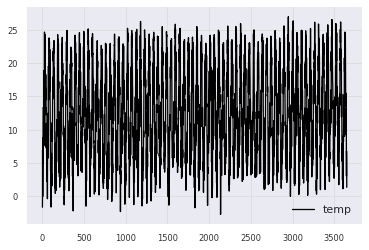

```python
sd_temp_val = anom.temp.sel(lon=-117,lat=33,method = 'nearest').values

sd_temp_df = pd.DataFrame(sd_temp_val)

sd_temp_df.columns=['temp']

sd_temp_df.plot()
```

### Checking the stationarity of the data

So above plots shows that we do have seasonality but there is no trend. Let's check for below necessary conditions:

- Constant mean
- Constant variance
- Dickey-fuller test which produce a P value. The null hypothesis of the test is that the time series can be represented by a unit root, that it is not stationary (has some time-dependent structure). The alternate hypothesis (rejecting the null hypothesis) is that the time series is stationary.

**p-value > 0.05**: Fail to reject the null hypothesis (H0), the data has a unit root and is non-stationary.

**p-value <= 0.05**: Reject the null hypothesis (H0), the data does not have a unit root and is stationary.

```python
def test_stationarity(timeseries):

    '''This function calculate the rolling mean, rolling standard deviation and the dicky fuller test to calculate
      the stationary of the data. It takes pandas dataframe as a input arguement and calculates if the datafram is
      stationary or not based on the statistical result of ADF, and P value.

      Args:
       timeseries (dataframe): The only parameter.

       return:

       1. Plot of the time series with rolling mean and rolling standard deviation
       2. Dick fuller statistical test result with P value

     '''


    #Determine rolling statistics
    movingAverage = timeseries.rolling(window=7).mean()
    movingSTD = timeseries.rolling(window=7).std()

    #Plot rolling statistics
    plt.figure(figsize=(10,5))
    plt.plot(timeseries, color='blue', label='Original')
    plt.plot(movingAverage, color='red', label='Rolling Mean')
    plt.plot(movingSTD, color='black', label='Rolling Std')
    plt.legend(loc='best')
    plt.title('Rolling Mean & Standard Deviation')
    plt.show(block=False)

    #Perform Dickey–Fuller test:
    print('Results of Dickey Fuller Test:')
    weather_test = adfuller(timeseries['temp'], autolag='AIC')
    dfoutput = pd.Series(weather_test[0:4], index=['Test Statistic','p-value','#Lags Used','Number of Observations Used'])
    print(dfoutput)
    if dfoutput[1] <= 0.05:
        print("\nstrong evidence against the null hypothesis(Ho), reject the null hypothesis. Data has no unit root and is stationary.")
    else:
        print("\nweak evidence against null hypothesis, time series has a unit root, indicating it is non-stationary.")
```

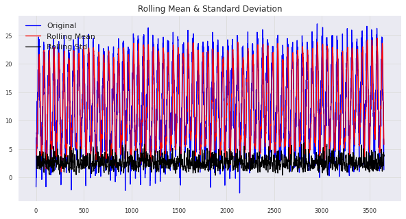

```
Results of Dickey Fuller Test:
Test Statistic                  -22.812731
p-value                           0.000000
#Lags Used                       30.000000
Number of Observations Used    3621.000000
dtype: float64

strong evidence against the null hypothesis(Ho), reject the null hypothesis. Data has no unit root and is stationary.
```

```python
test_stationarity(sd_temp_df)
```

### Checking the data in a smaller temporal scale for clarity

It shows from the above plot, the time series is stationary. However, to demonstrate the whole procedure, we are slicing the dataset for a smaller temporal scale (4 years) to detect the stationary test.

```python
weeks_in_year = 52

sd_temp_df_4year = sd_temp_df[:(4*weeks_in_year)]
```

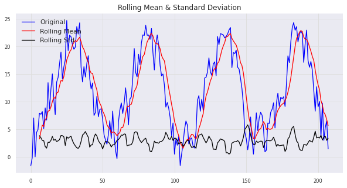

```
Results of Dickey Fuller Test:
Test Statistic                  -5.496557
p-value                          0.000002
#Lags Used                      15.000000
Number of Observations Used    192.000000
dtype: float64

strong evidence against the null hypothesis(Ho), reject the null hypothesis. Data has no unit root and is stationary.
```

```python
test_stationarity(sd_temp_df_4year)
```

## Optimal parameter tuning for ARIMA model

In this part, we are finding the best hyper parameter, namely p (the order of the auto-regressive model), d (order of first-differencing) and q (the order of the moving-average) of the arima model.

```python
from pmdarima import auto_arima

# Ignore harmless warnings

import warnings

warnings.filterwarnings("ignore")
```

```python
# Model Run

stepwise_fit = auto_arima(sd_temp_df,suppress_warnings=True)

stepwise_fit.summary()
```

SARIMAX Results

| Dep. Variable: | y | No. Observations: | 3652 |
| --- | --- | --- | --- |
| Model: | SARIMAX(2, 0, 3) | Log Likelihood | -8508.050 |
| Date: | Fri, 16 Sep 2022 | AIC | 17030.099 |
| Time: | 15:55:32 | BIC | 17073.521 |
| Sample: | 0 | HQIC | 17045.562 |
|  | - 3652 |  |  |
| Covariance Type: | opg |  |  |

|  | coef | std err | z | P>\|z\| | [0.025 | 0.975] |
| --- | --- | --- | --- | --- | --- | --- |
| intercept | 0.1828 | 0.003 | 67.531 | 0.000 | 0.178 | 0.188 |
| ar.L1 | 1.9770 | 0.002 | 1160.656 | 0.000 | 1.974 | 1.980 |
| ar.L2 | -0.9913 | 0.002 | -585.858 | 0.000 | -0.995 | -0.988 |
| ma.L1 | -1.4809 | 0.016 | -91.373 | 0.000 | -1.513 | -1.449 |
| ma.L2 | 0.2490 | 0.028 | 8.837 | 0.000 | 0.194 | 0.304 |
| ma.L3 | 0.2523 | 0.016 | 15.901 | 0.000 | 0.221 | 0.283 |
| sigma2 | 6.2891 | 0.152 | 41.454 | 0.000 | 5.992 | 6.586 |

| Ljung-Box (L1) (Q): | 0.07 | Jarque-Bera (JB): | 30.08 |
| --- | --- | --- | --- |
| Prob(Q): | 0.80 | Prob(JB): | 0.00 |
| Heteroskedasticity (H): | 0.93 | Skew: | -0.22 |
| Prob(H) (two-sided): | 0.24 | Kurtosis: | 3.05 |

Warnings:  
[1] Covariance matrix calculated using the outer product of gradients (complex-step).

In this above result, the value of P, d, and Q are retreived fromt the second row variable, named **Model**.

### Creating the training and testing data

We are splitting the dataset into 80% training and 20% testing part for this mode.

```python
print(sd_temp_df.shape)

train=sd_temp_df.iloc[:(round(len(sd_temp_df)*0.8)-len(sd_temp_df))]

test=sd_temp_df.iloc[(round(len(sd_temp_df)*0.8)-len(sd_temp_df)):]

print(train.shape,test.shape)

print(test.iloc[0],test.iloc[-1])
```

```
(3652, 1)
(2922, 1) (730, 1)
temp    8.240835
Name: 2922, dtype: float32 temp    1.352505
Name: 3651, dtype: float32
```

### Training the Model

```python
model=ARIMA(train['temp'],order=(2,0,3)) # Order value is retreive from p,d and q from the optimal parameter part.

model=model.fit()

model.summary()
```

SARIMAX Results

| Dep. Variable: | temp | No. Observations: | 2922 |
| --- | --- | --- | --- |
| Model: | ARIMA(2, 0, 3) | Log Likelihood | -6744.500 |
| Date: | Fri, 16 Sep 2022 | AIC | 13503.000 |
| Time: | 15:55:39 | BIC | 13544.860 |
| Sample: | 0 | HQIC | 13518.077 |
|  | - 2922 |  |  |
| Covariance Type: | opg |  |  |

|  | coef | std err | z | P>\|z\| | [0.025 | 0.975] |
| --- | --- | --- | --- | --- | --- | --- |
| const | 12.5591 | 0.063 | 200.405 | 0.000 | 12.436 | 12.682 |
| ar.L1 | 1.9855 | 3.76e-06 | 5.27e+05 | 0.000 | 1.986 | 1.986 |
| ar.L2 | -1.0000 | 2.92e-06 | -3.43e+05 | 0.000 | -1.000 | -1.000 |
| ma.L1 | -1.6060 | 0.016 | -97.882 | 0.000 | -1.638 | -1.574 |
| ma.L2 | 0.2477 | 0.032 | 7.663 | 0.000 | 0.184 | 0.311 |
| ma.L3 | 0.3779 | 0.016 | 23.009 | 0.000 | 0.346 | 0.410 |
| sigma2 | 5.8859 | 0.159 | 37.023 | 0.000 | 5.574 | 6.197 |

| Ljung-Box (L1) (Q): | 14.95 | Jarque-Bera (JB): | 28.86 |
| --- | --- | --- | --- |
| Prob(Q): | 0.00 | Prob(JB): | 0.00 |
| Heteroskedasticity (H): | 0.95 | Skew: | -0.24 |
| Prob(H) (two-sided): | 0.38 | Kurtosis: | 2.94 |

Warnings:  
[1] Covariance matrix calculated using the outer product of gradients (complex-step).

### Make Predicition on the test set and Error calculation

We are plotting the test set with the prediction from the ARIMA model. Also, we are calculation Root mean square error between observed and real value in the next cell.

```python
start=len(train)

end=len(train)+len(test)-1

pred=model.predict(start=start,end=end)

pred = pred.reset_index(drop=True)

test_temp = test['temp'].reset_index(drop=True)
```

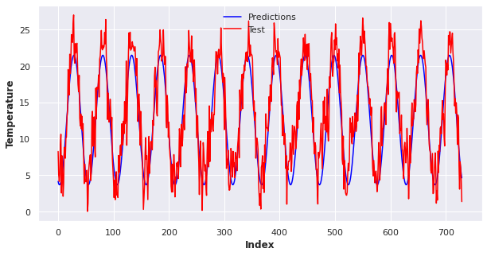

```python
import seaborn as sns
sns.set_theme(style="darkgrid")
plt.figure(figsize=[10, 5])
sns.lineplot(pred,color='blue',label='Predictions')
sns.lineplot(test_temp,color='red',label='Test')
plt.ylabel('Temperature')
plt.xlabel('Index')
plt.legend(loc='best')
```

```python
# Error calculation

from sklearn.metrics import mean_squared_error

from math import sqrt

rmse=sqrt(mean_squared_error(pred,test['temp']))

print("The root mean square error between prediction and the observation is {}".format(rmse))
```

```
The root mean square error between prediction and the observation is 2.805111444404489
```

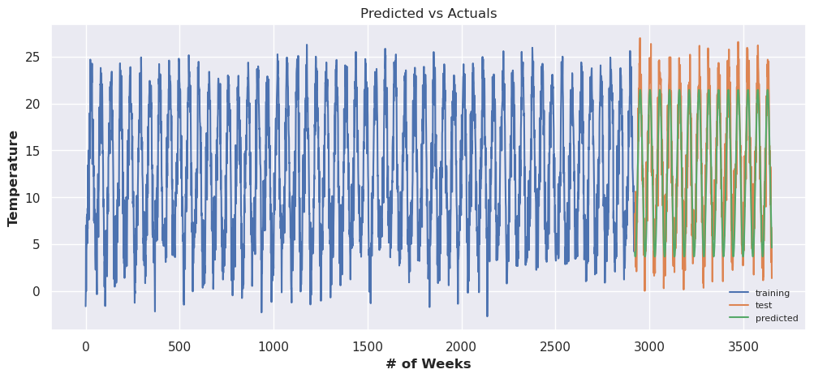

```python
# Final Plot with the whole dataset

#fc_series = pd.Series(pred, index=test['temp'].index)
pred=model.predict(start=start,end=end)

# # Plot
plt.figure(figsize=(12,5), dpi=100)
plt.plot(train, label='training')
plt.plot(test, label='test')
plt.plot(pred, label='predicted')
plt.title('Predicted vs Actuals')
plt.ylabel('Temperature')
plt.xlabel ('# of Weeks')
plt.legend(loc='lower right', fontsize=8)
plt.show()
```

## Testing the out of sample data

We have downloaded the preprocess the ERA5 reanalyis data for weekly resolution and substract the mean from the values to capture the anamolies.

```python
url = ('https://drive.google.com/file/d/1YINLBwmyEuJm3MS_HQzv4HELcWBQHPBa/view?usp=sharing')
path = 'https://drive.google.com/uc?export=download&id='+url.split('/')[-2]
df_oos = pd.read_csv(path)
```

```python
df_oos = df_oos[1:]
```

```python
fc_comp = model.predict(start = end,end = end+2*weeks_in_year,dynamic =True)
```

```python
fc_comp_series = fc_comp.reset_index()
fc_comp_series = fc_comp_series[1:]
fc_comp_series = fc_comp_series['predicted_mean']
```

```python
fc_X = fc_comp_series.to_xarray()
df_oos_X = df_oos.to_xarray()
```

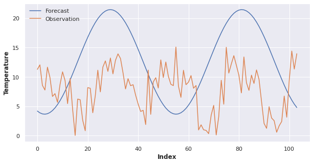

```python
sns.set_theme(style="darkgrid")
plt.figure(figsize=[10, 5])

sns.lineplot(fc_X,label='Forecast')
sns.lineplot(df_oos_X.New_temp,label='Observation')

plt.ylabel('Temperature')
plt.xlabel('Index')
plt.legend(loc='best')
```

### Error Calculation

```python
r = xs.pearson_r(df_oos_X.New_temp,fc_X,dim='index')
p = xs.pearson_r_p_value(df_oos_X.New_temp,fc_X, dim="index")
sp_r = xs.spearman_r(df_oos_X.New_temp,fc_X, dim="index")
mae = xs.mae(df_oos_X.New_temp,fc_X)
rmse = xs.rmse(df_oos_X.New_temp,fc_X)
```

```python
from tabulate import tabulate
d = [["RMSE", rmse.values],
    ["Pearson Coeff", r.values],
    ['Spearman coefficient',sp_r.values],
     ['Mean average value', mae.values],
    ['Pearson Correlation p value', p.values]]

print(tabulate(d,headers=['Deterministic Metrics', 'Values']))
```

```
Deterministic Metrics           Values
---------------------------  ---------
RMSE                         8.64192
Pearson Coeff                0.0561385
Spearman coefficient         0.0807319
Mean average value           7.80924
Pearson Correlation p value  0.571373
```

# Conclusion

Statistical model is not very optimized and efficieint to capture the complex relationship of the atmospheric variables like temperature, mean sea level pressure etc. However, it can give us a sense of climatology of the place and after calibration and bias correction of the model, a better prediction can be acheived.

# Neural Network model approach

In this approach, we are going to implement **LSTM (long short-term memory)** model to predict the temperature.

```python
import torch
import torch.nn as nn
import torch.optim as optim
import numpy as np
import pandas as pd
import shutil
from sklearn.preprocessing import MinMaxScaler
from tqdm import tqdm_notebook as tqdm

from torch.utils.tensorboard import SummaryWriter
import matplotlib.pyplot as plt

from darts import TimeSeries
from darts.dataprocessing.transformers import Scaler
from darts.models import RNNModel, ExponentialSmoothing, BlockRNNModel
from darts.metrics import mape
from darts.utils.statistics import check_seasonality, plot_acf
from darts.datasets import AirPassengersDataset, SunspotsDataset
from darts.utils.timeseries_generation import datetime_attribute_timeseries

import warnings

warnings.filterwarnings("ignore")
import logging

logging.disable(logging.CRITICAL)
import pandas
```

```python
ss = sd_temp.to_dataframe()
```

```python
lstm_ts = TimeSeries.from_dataframe(ss)

train, val = lstm_ts.split_after(pd.Timestamp("20000101"))
```

```python
# Read data:
#series = AirPassengersDataset().load()

# Create training and validation sets:
#train, val = series.split_after(pd.Timestamp("19590101"))

# Normalize the time series (note: we avoid fitting the transformer on the validation set)
transformer = Scaler()
train_transformed = transformer.fit_transform(train)
val_transformed = transformer.transform(val)
series_transformed = transformer.transform(lstm_ts)
```

```python
# create month and year covariate series
year_series = datetime_attribute_timeseries(
    pd.date_range(start=lstm_ts.start_time(), freq=lstm_ts.freq_str, periods=1000),
    attribute="year",
    one_hot=False,
)
year_series = Scaler().fit_transform(year_series)
week_series = datetime_attribute_timeseries(
    year_series, attribute="week", one_hot=True
)
covariates = year_series.stack(week_series)
cov_train, cov_val = covariates.split_after(pd.Timestamp("19590101"))
```

```python
my_model = BlockRNNModel(
    model="LSTM",
    input_chunk_length=16,
    output_chunk_length=4,
    dropout=0.1,
    batch_size=8,
    n_epochs=10,
    optimizer_kwargs={"lr": 1e-3},
    model_name="temp_RNN",
    log_tensorboard=True,
    random_state=42,
    force_reset=True,
    save_checkpoints=True,
)
```

```python
my_model.fit(
    train_transformed,
    val_series=val_transformed,
    verbose=True,
)
```

```
Validation: 0it [00:00, ?it/s]
Validation: 0it [00:00, ?it/s]
Validation: 0it [00:00, ?it/s]
Validation: 0it [00:00, ?it/s]
Validation: 0it [00:00, ?it/s]
Validation: 0it [00:00, ?it/s]
Validation: 0it [00:00, ?it/s]
Validation: 0it [00:00, ?it/s]
Validation: 0it [00:00, ?it/s]
Validation: 0it [00:00, ?it/s]
```

```
<darts.models.forecasting.block_rnn_model.BlockRNNModel at 0x7fb6de65e2b0>
```

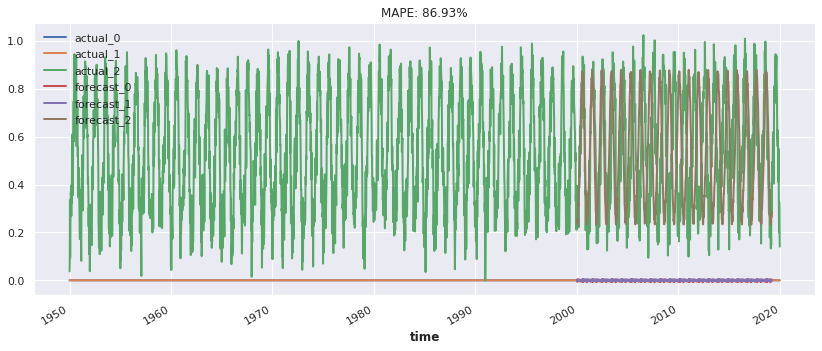

```python
def eval_model(model):
    pred_series = model.predict(n=1000)
    plt.figure(figsize=(14, 5))
    series_transformed.plot(label="actual")
    pred_series.plot(label="forecast")
    plt.title("MAPE: {:.2f}%".format(mape(pred_series, val_transformed)))
    plt.legend()


eval_model(my_model)
```

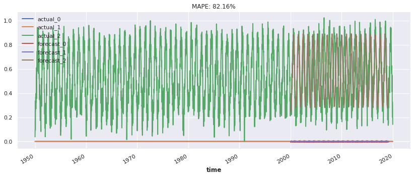

```python
best_model = RNNModel.load_from_checkpoint(model_name="temp_RNN", best=True)
eval_model(best_model)
```

```python
!pip install nbconvert
```